# Heart Disease Prediction: Model Comparison and Analysis

James Obanla

2024-12-31

### 1. Introduction:

One of the reasons for the human population’s loss of life is heart disease. This project is focused on comparing models built using exogenous variables such as age, sex, number of major vessels, serum cholesterol, resting blood pressure, chest pain, etc. to predict the target—the presence or absence of heart disease as the dependent variable. The sample size of datasets available for this task is 303 observations and 14 variables containing qualitative and quantitative data. The results derived from the support vector machine and logistic regression models are thoroughly analyzed and compared, leading to data-driven recommendations based on their respective performances

### 2. Loading Necessary Packages

Packages for data manipulation, visualization, and machine learning are loaded.

```r
library(tidyverse)
library(reshape2)
library(ggplot2)
library(caTools)
library(e1071)
library(randomForest)
```

```r
library(gt)
```

### 3. Loading and Inspecting Data

The heart dataset is loaded, and its structure and initial rows are reviewed.

```r
data<-read.csv(file.choose(), header = TRUE)

attach(data)

head(data)
```

```
##   Age Sex    ChestPain RestBP Chol Fbs RestECG MaxHR ExAng Oldpeak Slope Ca
## 1  63   1      typical    145  233   1       2   150     0     2.3     3  0
## 2  67   1 asymptomatic    160  286   0       2   108     1     1.5     2  3
## 3  67   1 asymptomatic    120  229   0       2   129     1     2.6     2  2
## 4  37   1   nonanginal    130  250   0       0   187     0     3.5     3  0
## 5  41   0   nontypical    130  204   0       2   172     0     1.4     1  0
## 6  56   1   nontypical    120  236   0       0   178     0     0.8     1  0
##         Thal Target
## 1      fixed      0
## 2     normal      1
## 3 reversable      1
## 4     normal      0
## 5     normal      0
## 6     normal      0
```

### 4. Data Cleaning

Handle duplicates, missing values, and encode categorical variables for analysis.

```r
data %>% filter(duplicated(.))
```

```
##  [1] Age       Sex       ChestPain RestBP    Chol      Fbs       RestECG
##  [8] MaxHR     ExAng     Oldpeak   Slope     Ca        Thal      Target
## <0 rows> (or 0-length row.names)
```

```r
any(is.na(data))
```

```
## [1] TRUE
```

```r
data <- data %>% drop_na()  ## removing of missing data

data_n <- data %>%
  mutate(
    ChestPain = ifelse(ChestPain == "typical", 1,
                       ifelse(ChestPain == "asymptomatic", 2,
                              ifelse(ChestPain == "nonanginal", 3,
                                     ifelse(ChestPain == "nontypical", 4, NA)))),
    Thal = ifelse(Thal == "normal", 1,
                  ifelse(Thal == "fixed", 2,
                         ifelse(Thal == "reversable", 3, NA))),
    Thal = ifelse(is.na(Thal), mean(Thal, na.rm = TRUE), Thal)
  )

tail(data_n)
```

```
##     Age Sex ChestPain RestBP Chol Fbs RestECG MaxHR ExAng Oldpeak Slope Ca Thal
## 296  57   0         2    140  241   0       0   123     1     0.2     2  0    3
## 297  45   1         1    110  264   0       0   132     0     1.2     2  0    3
## 298  68   1         2    144  193   1       0   141     0     3.4     2  2    3
## 299  57   1         2    130  131   0       0   115     1     1.2     2  1    3
## 300  57   0         4    130  236   0       2   174     0     0.0     2  1    1
## 301  38   1         3    138  175   0       0   173     0     0.0     1  2    1
##     Target
## 296      1
## 297      1
## 298      1
## 299      1
## 300      1
## 301      0
```

```r
summary(data_n)
```

```
##       Age             Sex           ChestPain         RestBP
##  Min.   :29.00   Min.   :0.0000   Min.   :1.000   Min.   : 94.0
##  1st Qu.:48.00   1st Qu.:0.0000   1st Qu.:2.000   1st Qu.:120.0
##  Median :56.00   Median :1.0000   Median :2.000   Median :130.0
##  Mean   :54.45   Mean   :0.6811   Mean   :2.538   Mean   :131.7
##  3rd Qu.:61.00   3rd Qu.:1.0000   3rd Qu.:3.000   3rd Qu.:140.0
##  Max.   :77.00   Max.   :1.0000   Max.   :4.000   Max.   :200.0
##       Chol            Fbs            RestECG         MaxHR
##  Min.   :126.0   Min.   :0.0000   Min.   :0.00   Min.   : 71.0
##  1st Qu.:211.0   1st Qu.:0.0000   1st Qu.:0.00   1st Qu.:134.0
##  Median :242.0   Median :0.0000   Median :1.00   Median :153.0
##  Mean   :246.9   Mean   :0.1462   Mean   :0.99   Mean   :149.7
##  3rd Qu.:275.0   3rd Qu.:0.0000   3rd Qu.:2.00   3rd Qu.:166.0
##  Max.   :564.0   Max.   :1.0000   Max.   :2.00   Max.   :202.0
##      ExAng           Oldpeak          Slope             Ca
##  Min.   :0.0000   Min.   :0.000   Min.   :1.000   Min.   :0.000
##  1st Qu.:0.0000   1st Qu.:0.000   1st Qu.:1.000   1st Qu.:0.000
##  Median :0.0000   Median :0.800   Median :2.000   Median :0.000
##  Mean   :0.3256   Mean   :1.043   Mean   :1.601   Mean   :0.691
##  3rd Qu.:1.0000   3rd Qu.:1.600   3rd Qu.:2.000   3rd Qu.:1.000
##  Max.   :1.0000   Max.   :6.200   Max.   :3.000   Max.   :3.000
##       Thal           Target
##  Min.   :1.000   Min.   :0.0000
##  1st Qu.:1.000   1st Qu.:0.0000
##  Median :1.000   Median :0.0000
##  Mean   :1.837   Mean   :0.4585
##  3rd Qu.:3.000   3rd Qu.:1.0000
##  Max.   :3.000   Max.   :1.0000
```

### 5. Exploratory Data Analysis

Boxplots are created to explore variable distributions by the target class.

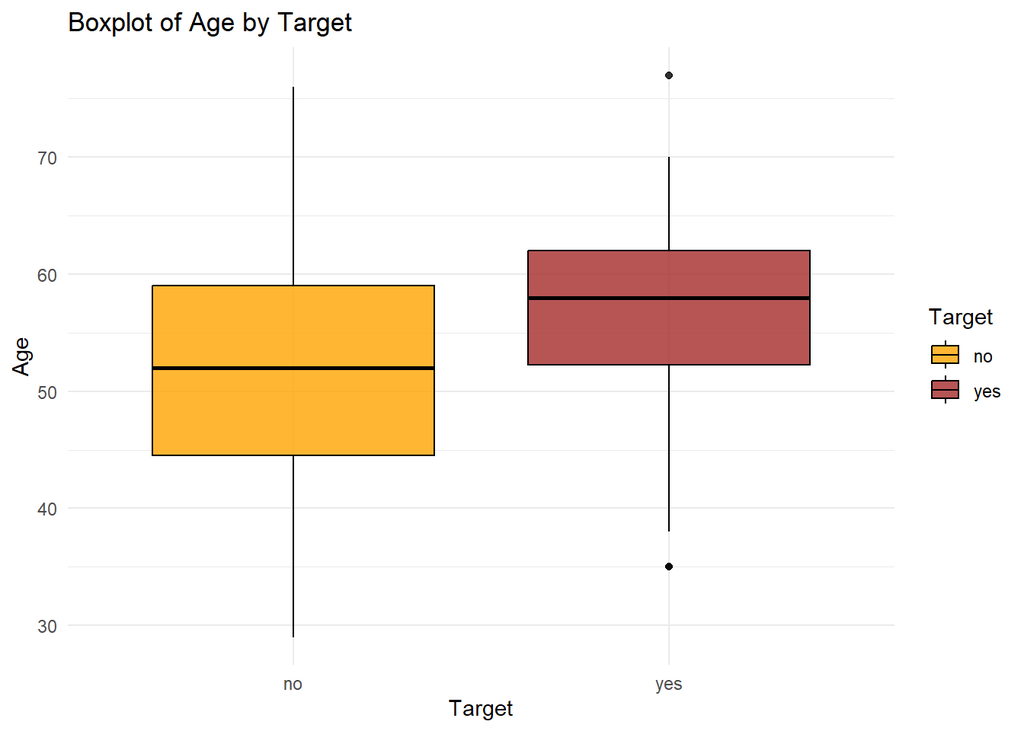

```r
# Ensure Target is a factor with the correct levels
data_n$Target <- factor(ifelse(data_n$Target == 0, "no", "yes"), levels = c("no", "yes"))

# Create the boxplot
data1 <- ggplot(data_n, aes(x = Target, y = Age, fill = Target)) +
  geom_boxplot(alpha = 0.8, color = "black") +
  theme_minimal() +
  labs(title = "Boxplot of Age by Target",
       x = "Target",
       y = "Age") +
  scale_fill_manual(values = c("no" = "orange", "yes" = "brown"))

# Display the plot
data1
```

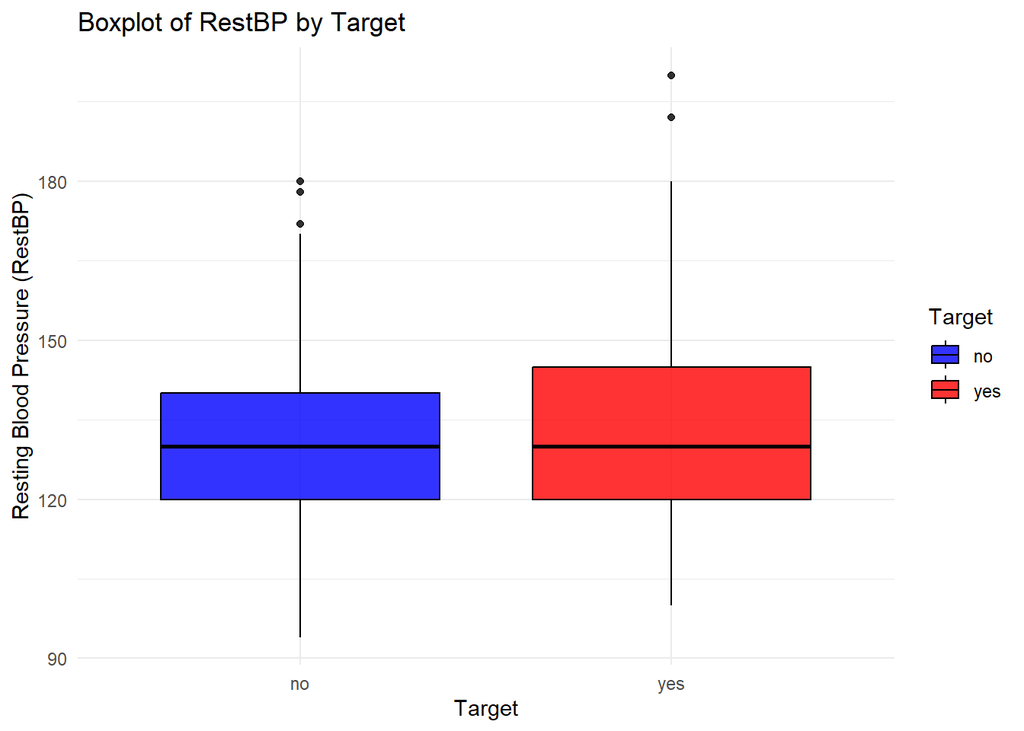

```r
# Create the boxplot for RestBP by Target
data2 <- ggplot(data_n, aes(x = Target, y = RestBP, fill = Target)) +
  geom_boxplot(alpha = 0.8, color = "black") +
  theme_minimal() +
  labs(title = "Boxplot of RestBP by Target",
       x = "Target",
       y = "Resting Blood Pressure (RestBP)") +
  scale_fill_manual(values = c("no" = "blue", "yes" = "red"))

# Display the plot
data2
```

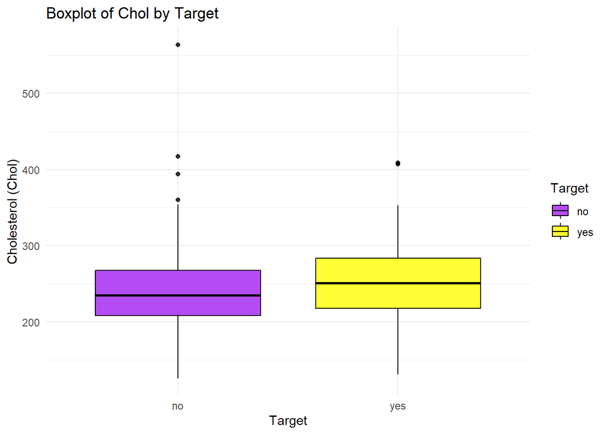

```r
# Create the boxplot for Chol by Target
data3 <- ggplot(data_n, aes(x = Target, y = Chol, fill = Target)) +
  geom_boxplot(alpha = 0.8, color = "black") +
  theme_minimal() +
  labs(title = "Boxplot of Chol by Target",
       x = "Target",
       y = "Cholesterol (Chol)") +
  scale_fill_manual(values = c("no" = "purple", "yes" = "yellow"))

# Display the plot
data3
```

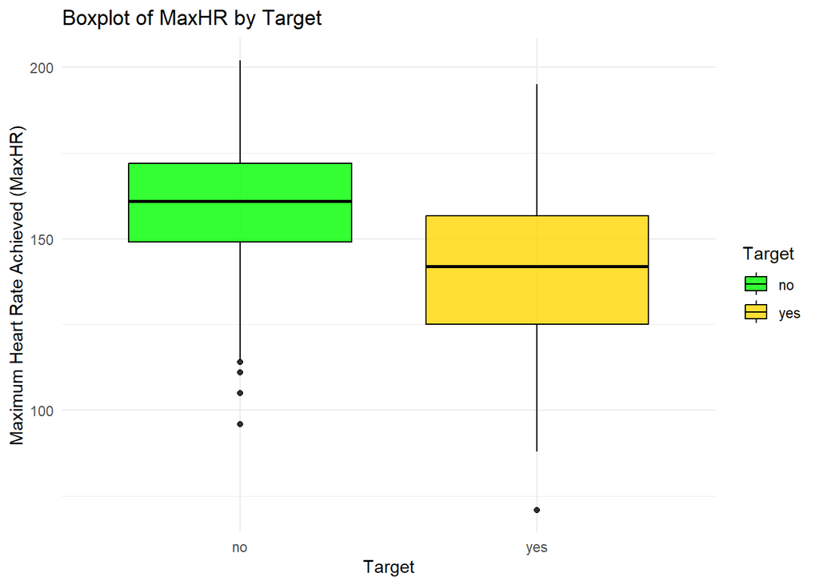

```r
data4 <- ggplot(data_n, aes(x = Target, y = MaxHR, fill = Target)) +
  geom_boxplot(alpha = 0.8, color = "black") +
  theme_minimal() +
  labs(title = "Boxplot of MaxHR by Target",
       x = "Target",
       y = "Maximum Heart Rate Achieved (MaxHR)") +
  scale_fill_manual(values = c("no" = "green", "yes" = "gold"))

data4
```

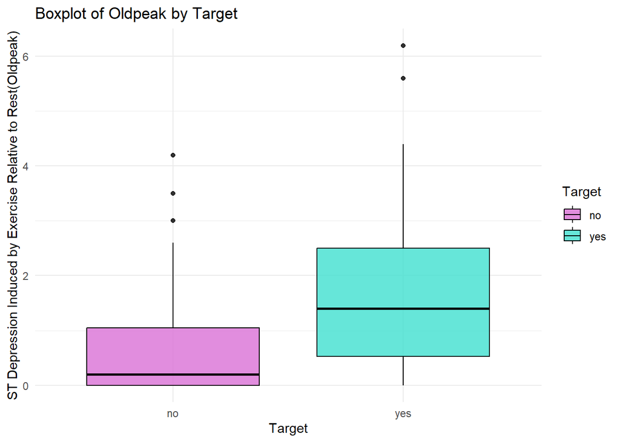

```r
data5 <- ggplot(data_n, aes(x = Target, y = Oldpeak, fill = Target)) +
  geom_boxplot(alpha = 0.8, color = "black") +
  theme_minimal() +
  labs(title = "Boxplot of Oldpeak by Target",
       x = "Target",
       y = "ST Depression Induced by Exercise Relative to Rest(Oldpeak)") +
  scale_fill_manual(values = c("no" = "orchid", "yes" = "turquoise"))

data5
```

### 6. Correlation Heatmap

A correlation matrix heatmap is created for independent variables, separated by dependent variable-Target.

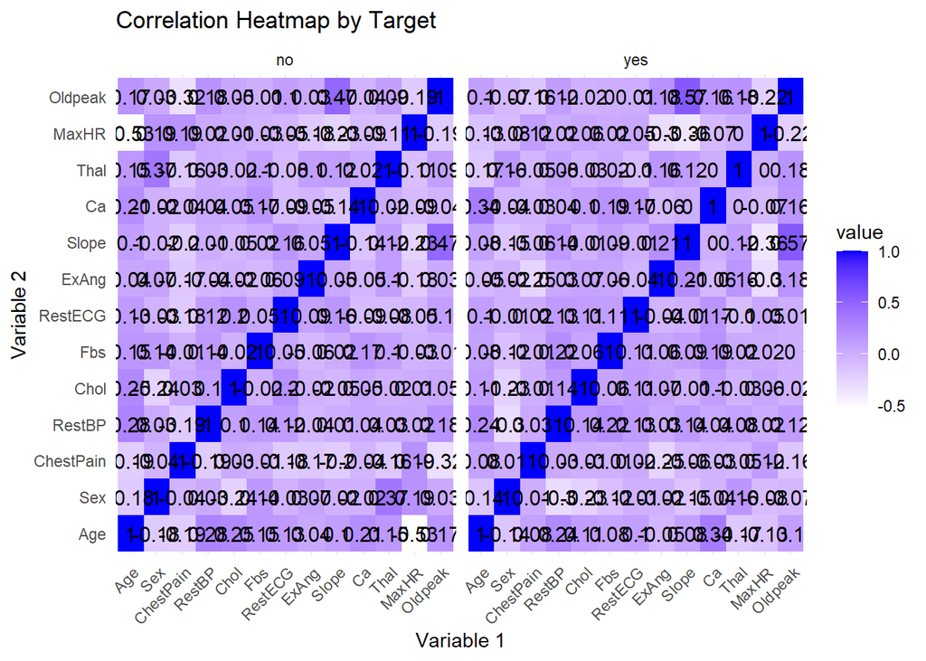

```r
# Select numeric variables for correlation
data6 <- data_n[, c("Age", "Sex", "ChestPain", "RestBP", "Chol", "Fbs",
                    "RestECG", "ExAng", "Slope", "Ca", "Thal", "MaxHR", "Oldpeak")]

# Ensure Target is treated as a categorical variable
data_n$Target <- factor(data_n$Target)

# Compute correlation matrices separately for each Target category
cor_by_target <- lapply(split(data6, data_n$Target), function(subset) {
  cor(subset, use = "complete.obs")
})

# Convert the correlation matrices into long format and add Target labels
cor_melted_list <- lapply(names(cor_by_target), function(target) {
  melted <- reshape2::melt(cor_by_target[[target]])
  melted$Target <- target
  return(melted)
})

# Combine all melted data into a single data frame
data7 <- do.call(rbind, cor_melted_list)

# Plot the heatmap with correlation values
ggplot(data7, aes(x = Var1, y = Var2, fill = value)) +
  geom_tile() +
  geom_text(aes(label = round(value, 2)), size = 4, color = "black") +  # Add correlation values
  scale_fill_gradient(low = "white", high = "blue") +
  facet_wrap(~ Target) +  # Separate heatmaps for each Target category
  labs(title = "Correlation Heatmap by Target",
       x = "Variable 1", y = "Variable 2") +
  theme_minimal() +
  theme(axis.text.x = element_text(angle = 45, hjust = 1))
```